# Master programming

Домашнее задание

Игорь Шаронов

2021-09-05

# Описание домашней работы

# Из чего состоят задания

- Домашнее задание <=> лабораторные работы
- 1 задание на ознакомление с системой проверки (3 балла)
- 6 заданий на написание кода (11 баллов)
- 1 задание на написание теста (11 баллов)
- всего 8 заданий с общим весом в 80 баллов
- 5 дополнительных вопросов для самопроверки
- 5 дополнительных заданий на самостоятельную работу

# Порядок сдачи лабораторной работы

- Создаём пулл-реквест со сделанной и протестированной лабораторной
- Вешаем его на `igsha`
- Получаем список замечаний
- Исправляем замечания поверх старого кода, без добавления коммита:

  ```
  git commit -a --amend
  git push --force
  ```

- Получаем новые замечания и идём на предыдущий пункт
- Если всё в порядке, `igsha` примет пулл-реквест и замёржит изменения в мастер
- В комментарии будет количество набранных баллов:
  - Если всё исправлено и замечаний больше нет, то максимальное количество баллов
  - Возможен торг: некоторые замечания можно не исправлять, тогда просто снизится количество баллов
  - За просрок баллы нельзя добрать, только с помощью ответов на вопросы в конце семестра

# Снижение баллов

- Каждая лабораторная сдаётся в течение 2-х недель
- По истечении срока максимальный балл **каждый раз** снижается на 1
- Меньше 6 баллов за лабораторную нельзя получить
  - Если такая ситуация возникает, торговаться уже не получится: надо исправить **все** замечания
- Замечания к лабораторным:
  - Критичные — какая-то функциональность сделана неправильно (торг не уместен)
  - Некритичные (nit-pick) — что-то можно сделать удобнее/лучше/нагляднее (торг уместен)
- За списывание снижение безвозвратно -2 балла + даётся дополнительное задание. Если исправления тоже списаны, тогда ещё -2 балла.
- За первую лабораторную снижение баллов не происходит (только если не списано 🤦)

# Инициализация репозитория

# Использование ссылки-приглашения

- По надёжным каналам связи высылается специальная ссылка-приглашение
- Авторизоваться на https://github.com
- Перейти по ссылке-приглашению (возможно нужно дать доступ для classroom.github.com)
- У каждого студента будет создан приватный репозиторий в организации `cvlabmiet`

# Настройка слияний веток

- Каждая лабораторная делается в своей ветке
- Допускается только рибейз веток
- **Не допускаются коммиты напрямую в мастер**

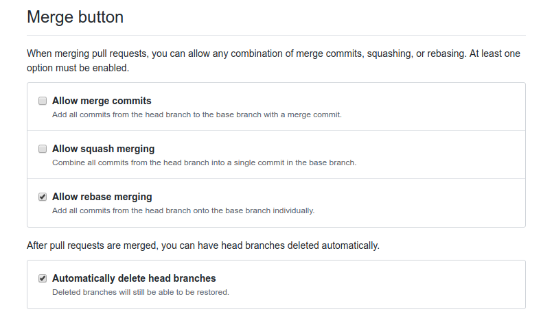

# Интеграция в пулл-реквесты

# Автоматическая проверка

- Если всё настроено правильно, то при очередном пулл-реквесте будет показана информация о сборке проекта
- Автоматическая сборка исходников на базе docker + nix-shell
- Автоматический запуск тестов
- **Невозможность слияния веток в мастер при наличии ошибок**

[figure not shown]

# Github-Actions

- Для проверки собираемости заданий используется сервис непрерывной интеграции github-actions
- Сервис доступен автоматически, ничего настраивать не нужно
- При создании пулл-реквеста сервис соберёт и протестирует новые изменения

[figure not shown]

# Пример пулл-реквеста

- В настройках пользователя написать своё имя (либо в сообщении пулл-реквеста)
- В тело сообщения вставить лог прохождения тестов
- В reviewers или assignees назначить `igsha`
- Все автоматические проверки должны быть успешно пройдены

[figure not shown]

# Способы сборки проекта

# Платформа Linux

Два способа сборки проекта

1. Вручную устанавливаем нужные пакеты
   - `gnumake` (можно `ninja`)
   - `cmake` версии не ниже 3.12
   - `gcc` или `clang` с поддержкой 17-го стандарта C++
   - `catch2` версии не ниже 2.8
   - `boost` версии не ниже 1.68
   - `gdb` для отладки кода
2. Используя nix-shell
   - устанавливаем [nix-shell](https://nixos.org/nix/) по команде `curl -L https://nixos.org/nix/install | sh`
   - в корне проекта вызываем команду `nix-shell`. После этого `nix` сам установит и скачает нужные пакеты

# Платформа Windows

- Разработка будет вестись с помощью Visual Studio Community (бесплатная лицензия)
- Поддержка `cmake` уже встроена в студию
- Пакеты `boost` и `catch2` будем устанавливать с помощью `vcpkg`
- По желанию можно поставить [плагин](https://marketplace.visualstudio.com/items?itemName=JohnnyHendriks.ext01) для отображения тестов `catch2`

Если есть желание и установленный WSL в системе, можно поиграться в nix-shell.

# Платформа Windows (установка и настройка VS)

- Устанавливаем [Visual Studio Community](https://visualstudio.microsoft.com/free-developer-offers)
- При установке указываем `Desktop development with C++`
- Выбираем дополнительный пакет `C++ CMake tools for Windows`

[figure not shown]

# Платформа Windows (установка пакетов)

- Используя Visual Studio клонируем проект https://github.com/Microsoft/vcpkg
  - Рекомендуется отключить автоматическую генерацию `cmake`
- Запускаем командную оболочку `Tools -> Command Line -> Developers Power Shell`
- Далее все команды делаются из одной и той же командной оболочки
- Собираем пакетный менеджер [vcpkg](https://docs.microsoft.com/ru-ru/cpp/build/vcpkg?view=vs-2019)
  - `.\bootstrap-vcpkg`
- Устанавливаем нужные пакеты
  - `.\vcpkg install catch2:x64-windows`
  - `.\vcpkg install boost:x64-windows`
  - установка занимает около 50 минут
- Интегрируем пакетный менеджер в Visual Studio
  - `.\vcpkg integrate install`
  - данная команда автоматически изменит cmake тулчейн для всех проектов
  - после этой команды надо будет перезапустить Visual Studio

# Платформа Windows (разработка)

- Открываем директорию с проектом (или клонируем его)
- Добавляем vcpkg пакеты в настройки проекта, согласно [инструкции](https://vcpkg.readthedocs.io/en/latest/examples/installing-and-using-packages/#cmake):
  - CMakeLists.txt -> Change Cmake Settings:

    ```
    "variables": [
        {
            "name": "CMAKE_TOOLCHAIN_FILE",
            "value": "[путь до vcpkg]/scripts/buildsystems/vcpkg.cmake"
        }
    ]
    ```

- Генерируем сборочное дерево (`Generate Cache`)
- Собираем проект привычным способом
- Запускаем тесты (либо через адаптер, либо `Test -> Run CTests`)
- Следим, чтобы в коммит не попало левых изменений (`CMakeSettings.json`, `out` и т.д.)

# Платформа Eclipse-Che (браузер)

- https://che.openshift.io
- Достаточно только браузера
- Логиниться на ресурс через github-аккаунт
- Создаём workspace из файла `eclipse-che.yml` внутри репозитория с заданиями
- Внутри workspace:
  - Ничего не сохраняется, поэтому надо свои изменения пушить на сервер
  - Перейти в настройки и установить почту для Git (`<username>@users.noreply.github.com`) — это влияет на ошибку пуша своей ветки на github
- Поддерживает intellisense (но не всё доступно, так как компиляция и GUI находятся в разных докерах)
- Поддерживает отладку (но не все объекты можно посмотреть)
- Поддерживает git: создание веток, коммит, пуш изменений на сервер
- Есть окно терминала для “тонкой” отладки
- См. видео лекцию по подготовке лабораторных работ